# hw07-ghosh17

Subhankar Ghosh

### Question 1

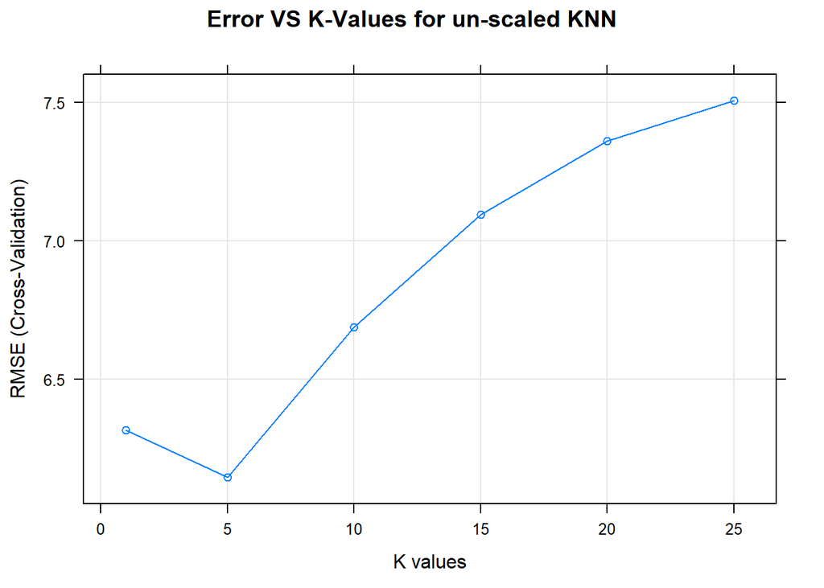

```r
library(caret)
library(mlbench)
library(klaR)

data(Boston, package = "MASS")
set.seed(42)
bstn_idx = createDataPartition(Boston$medv, p = 0.80, list = FALSE)
bstn_trn = Boston[bstn_idx, ]
bstn_tst = Boston[-bstn_idx, ]

# Linear Model
set.seed(1337)
lin_mod = train(
  medv ~ .,
  data = bstn_trn,
  method = "lm",
  trControl = trainControl(method = "cv", number = 5)
)

# Unscaled KNN
set.seed(1337)
bstn_knn_mod = train(
  medv ~ .,
  data = bstn_trn,
  method = "knn",
  trControl = trainControl(method = "cv", number = 5),
  tuneGrid = expand.grid(k = c(1, 5, 10, 15, 20, 25))
)

plot(bstn_knn_mod, xlab="K values", main="Error VS K-Values for un-scaled KNN")
```

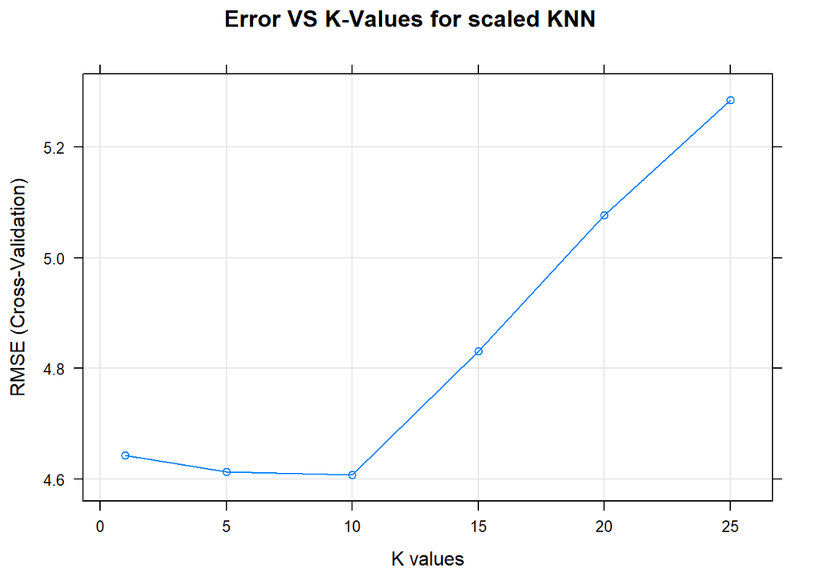

```r
# Scaled KNN
set.seed(1337)
bstn_knn_mod_scaled = train(
  medv ~ .,
  data = bstn_trn,
  method = "knn",
  trControl = trainControl(method = "cv", number = 5),
  preProcess = c("center", "scale"),
  tuneGrid = expand.grid(k = c(1, 5, 10, 15, 20, 25))
)

plot(bstn_knn_mod_scaled, xlab="K values", main="Error VS K-Values for scaled KNN")
```

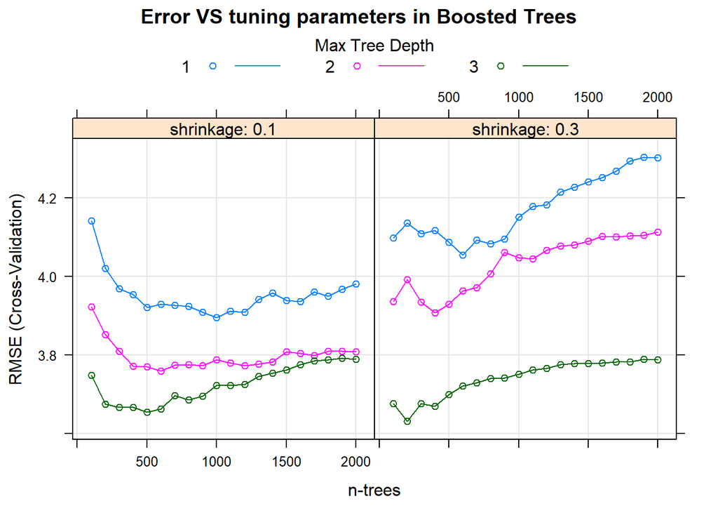

```r
#Random Forest
set.seed(1337)
bstn_rf_mod = train(
  medv ~ .,
  data = bstn_trn,
  method = "rf",
  trControl = trainControl(method = "cv", number = 5)
)

#Boosted Tree
gbm_grid = expand.grid(interaction.depth = c(1, 2, 3),
                       n.trees = (1:20) * 100,
                       shrinkage = c(0.1, 0.3),
                       n.minobsinnode = 20)

set.seed(1337)
bstn_gbm_mod = train(
  medv ~ .,
  data = bstn_trn,
  trControl = trainControl(method = "cv", number = 5),
  method = "gbm",
  tuneGrid = gbm_grid,
  verbose = FALSE
)

plot(bstn_gbm_mod, xlab="n-trees", main="Error VS tuning parameters in Boosted Trees")
```

```r
calc_rmse = function(actual, predicted) {
  sqrt(mean((actual - predicted) ^ 2))
}

df1 = data.frame(Model_Name = c("linear", "knn-unscaled", "knn-scaled", "random forest", "boosted tree"),
                 Test_Error = c(
                              calc_rmse(actual = bstn_tst$medv, predicted = predict(lin_mod, bstn_tst)),
                              calc_rmse(actual = bstn_tst$medv, predicted = predict(bstn_knn_mod, bstn_tst)),
                              calc_rmse(actual = bstn_tst$medv, predicted = predict(bstn_knn_mod_scaled, bstn_tst)),
                              calc_rmse(actual = bstn_tst$medv, predicted = predict(bstn_rf_mod, bstn_tst)),
                              calc_rmse(actual = bstn_tst$medv, predicted = predict(bstn_gbm_mod, bstn_tst))
                              ),
                 CV_RMSE = c(
                             lin_mod$results$RMSE,
                             min(bstn_knn_mod$results$RMSE),
                             min(bstn_knn_mod_scaled$results$RMSE),
                             min(bstn_rf_mod$results$RMSE),
                             min(bstn_gbm_mod$results$RMSE)
                             )
                 )

knitr::kable(df1, align = 'c')
```

| Model_Name | Test_Error | CV_RMSE |
| --- | --- | --- |
| linear | 4.989490 | 4.835444 |
| knn-unscaled | 6.491325 | 6.146077 |
| knn-scaled | 5.460893 | 4.607600 |
| random forest | 3.033097 | 3.277205 |
| boosted tree | 3.666415 | 3.632349 |

### Question 2

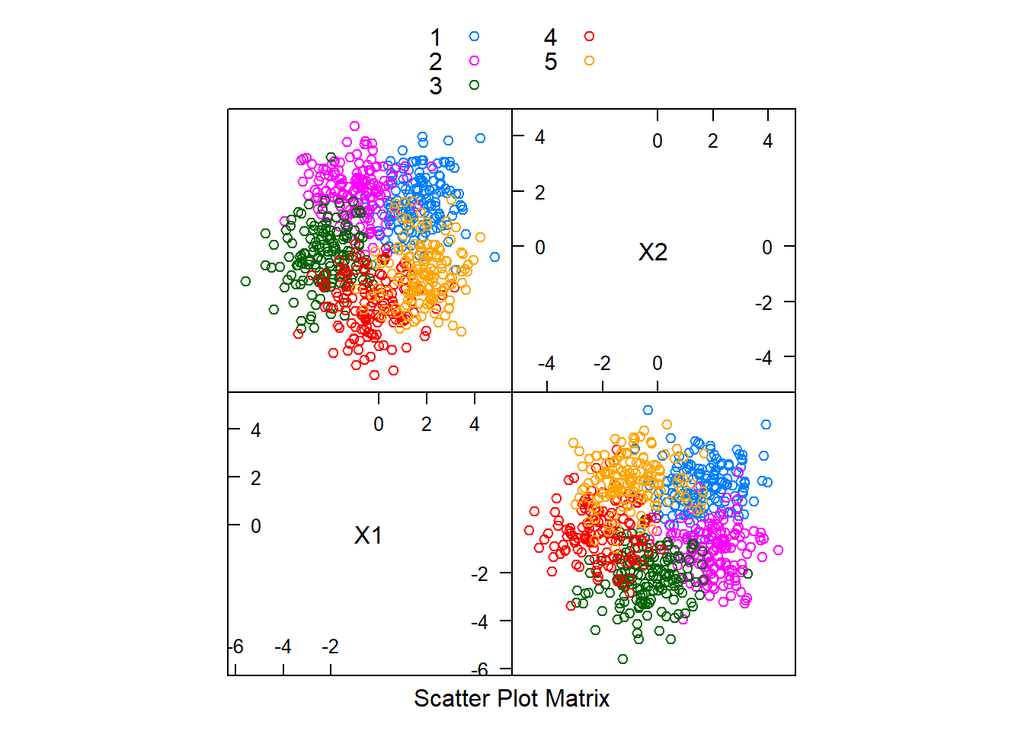

```r
set.seed(42)
sim_trn = mlbench::mlbench.2dnormals(n = 750, cl = 5)
sim_trn = data.frame(
  classes = sim_trn$classes,
  sim_trn$x
)

caret::featurePlot(x = sim_trn[, -1],
                   y = sim_trn$classes,
                   plot = "pairs",
                   auto.key = list(columns = 2))
```

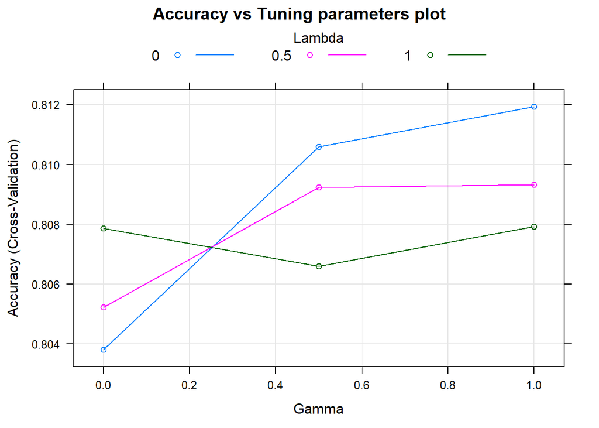

```r
set.seed(1337)
sim_lda = train(
  classes ~ .,
  data = sim_trn,
  trControl = trainControl(method = "cv", number = 10),
  method = "lda",
  verbose = FALSE
)

set.seed(1337)
sim_qda = train(
  classes ~ .,
  data = sim_trn,
  trControl = trainControl(method = "cv", number = 10),
  method = "qda",
  verbose = FALSE
)

set.seed(1337)
sim_nb = train(
  classes ~ .,
  data = sim_trn,
  trControl = trainControl(method = "cv", number = 10),
  method = "nb",
  verbose = FALSE
)

set.seed(1337)
sim_rda = train(
  classes ~ .,
  data = sim_trn,
  trControl = trainControl(method = "cv", number = 10),
  method = "rda",
  verbose = FALSE
)

plot(sim_rda, main = "Accuracy vs Tuning parameters plot")
```

```r
df2 = data.frame(Model_Name = c("LDA", "QDA", "Naive Bayes", "RDA"),
                 CV_Accuracy = c(sim_lda$results$Accuracy,
                                 sim_qda$results$Accuracy,
                                 max(sim_nb$results$Accuracy),
                                 max(sim_rda$results$Accuracy)),
                 Accuracy_Standard_Deviation = c(
                   sim_lda$results$AccuracySD,
                   sim_qda$results$AccuracySD,
                   sim_nb$results[which(sim_nb$results$Accuracy == max(sim_nb$results$Accuracy)), "AccuracySD"],
                   sim_rda$results[which(sim_rda$results$Accuracy == max(sim_rda$results$Accuracy)), "AccuracySD"]
                 ))

knitr::kable(df2, align = "c")
```

| Model_Name | CV_Accuracy | Accuracy_Standard_Deviation |
| --- | --- | --- |
| LDA | 0.8078610 | 0.0356863 |
| QDA | 0.8038074 | 0.0385323 |
| Naive Bayes | 0.8118103 | 0.0366514 |
| RDA | 0.8119350 | 0.0379171 |

### Question 3

1. What value of k is chosen for KNN without predictor scaling?

**k=5**

2. What value of k is chosen for KNN with predictor scaling?

**k=10**

3. What are the values of the tuning parameters chosen for the boosted tree model?

**The tuning paramters for the best boosted tree models: n.tree=200, interaction.depth=3, shrinkage=0.3, n.minobsinnode=20**

4. Which method achieves the lowest cross-validated error?

**Random Forest achieves the lowest cv error**

5. Which method achieves the lowest test error?

**Random Forest acieves the lowest test error**

6. What are the values of the tuning parameters chosen for the RDA model?

**The values of the tuning parameters chosen for the RDA model are Gamma = 1 and lambda = 0**

7. Based on the scatterplot, which method, LDA or QDA, do you think is more appropriate? Explain.

**LDA is more appropriate because from the scatter plot we can see that the variances of the predictors are almost equal across the classes and also the decision boundaries look to be linear.**

8. Based on the scatterplot, which method, QDA or Naive Bayes, do you think is more appropriate? Explain.

**Naive Bayes because the predictors look like independent and Naive bayes assumes independence of the predictors.**

1. Which model achieves the best cross-validated accuracy?

**RDA achieves the best cross-validated accuracy**

10. Do you believe the model in (i) is the model that should be chosen? Explain.

**No RDA is not the model that should be chosen. I believe Naive Bayes should be selected since the Accuracy of naive bayes is not very less than that of RDA and it is much more simpler computationally.**